# Taller 2 EST MAT

María Clara Avila, Alejandro Moya, David Ibañez, David Reyes, Mateo Giraldo

2025-04-30

# Punto 1

## Estimador metodo de momentos

Primero calculamos el momento poblacional. Como tenemos un solo parámetro a estimar usando el momento $k = 1$.

Entonces

$$m_1 = E(X)$$

Para una distribución uniforme en el intervalo $[0, \theta]$, tenemos que

$$E(X) = \frac{\theta}{2}$$

Ahora calculamos el primer momento muestral

$$M_1 = \frac{1}{n} \sum_{i=1}^n X_i =
\bar{X}$$

Ahora igualamos ambos momentos

$$m_1 = M_1$$
$$\frac{\theta}{2} = \bar{X}$$

De aquí despejamos $\theta$

$$\hat{\theta}_1 = 2\bar{X}$$

Ahora verificamos que nuestro estimador $\hat{\theta}_1$ es insesgado

$$E(\hat{\theta}_1) = E(2\bar{X}) =
2E\left(\frac{1}{n} \sum_{i=1}^n X_i\right) =
\frac{2}{n}E\left(\sum_{i=1}^n \frac{\theta}{2}\right) =
\frac{1}{n}E(n\theta) = E(\theta) = \theta$$

Entonces el estimador $\hat{\theta}_1$ es insesgado

## Estimador maxima verosimilitud

La función de densidad de probabilidad de para $X \backsim \text{Uniforme}[0, \theta]$ se define como

$$f_X(x) = \begin{cases}
\dfrac{1}{\theta} & \text{si } 0 \leq x \leq \theta, \\
0 & \text{en otro caso}.
\end{cases}$$

La función de verosimilitud la construimos como

$$L(\theta) = f(x_1, \dots, x_n ; \theta)
= \prod_{i=1}^n f_X(X_i)$$

Note que si $\theta < X_i$ para algún i, entonces $f_x(X_i) = 0$, por lo que

$$L(\theta) = 0$$

En el caso donde $\theta \geq X_i , \quad i = 1, \dots, n$, entonces

$$L(\theta) =
\left(\frac{1}{\theta}\right)^n = \frac{1}{\theta^n}$$

Entonces podemos expresar la función de verosimilitud como

$$L(\theta) = \begin{cases}
\dfrac{1}{\theta^n} & \theta \geq \text{max}(X_1, \dots, X_n) \\
0 & \text{en otro caso}
\end{cases}$$

Ahora como queremos maximizar la verosimilitud consideramos $\theta \geq \max(X_1, \dots, X_n)$ ya que $\theta > 0$ por lo que $0 < \dfrac{1}{\theta^n}$

Por otro lado, note que

$$\frac{d}{d\theta}\left(\frac{1}{\theta^n}\right)
= -\frac{1}{\theta^{n+1}} < 0$$

Por lo que la función $L$ es decreciente, entonces para maximizar la función de verosimilitud, tendremos que escoger minimizar nuestro $\theta$, pero como ya definimos como cota inferior $\theta \geq \max(X_1, \dots, X_n)$ entonces maximizamos $L$ con $\theta = \max(X_1, \dots, X_n)$

Entonces nuestro estimador de máxima verosimilitud es

$$\hat{\theta}_2 = \max(X_1, \dots,
X_n)$$

Para definir si es sesgado empezamos definiendo $Y = \max(X_1, \dots, X_n)$

$$P[Y \leq y] =
\left(\frac{y}{\theta}\right)^n \quad \text{para} \, 0 \leq y \leq
\theta$$

$$f_Y(y) = \frac{d}{dy}P[Y \leq y] =
\frac{ny^{n-1}}{\theta^n}$$

$$E(\hat{\theta}_2) = \int_0^\theta y
\cdot \frac{ny^{n-1}}{\theta^n} \,dy = \frac{n}{\theta^n} \int_0^\theta
y^n \, dy = \frac{n}{\theta^n} \cdot \frac{\theta^{n+1}}{n+1} =
\frac{n}{n+1}\theta$$

Note que

$$\frac{n}{n+1}\theta \neq
\theta$$

Por lo que el estimador es sesgado

$$\text{Sesgo}(\hat\theta_2) = E(\hat\theta_2) - \theta
= \frac{n}{n+1}\theta - \theta = \theta\left(\frac{n}{n+1}-1\right)$$

## Estimador por esperanza del minimo

Para una muestra $X_1, \dots, X_n \backsim \text{Uniforme}[0, \theta]$ la función de densidad del mínimo $m = \min(X_1, \dots, X_n)$ se calcula de la siguiente manera:

$$\begin{align*}
F_m(x) &= P(m \leq x) \\
&= 1 - P(m > x) \\
&= 1 - P(\text{todos los } X_i > x) \\
&= 1 - \prod_{i=1}^n P(X_i > x) \\
&= 1 - \left(1 - \frac{x}{\theta}\right)^n \quad \text{para } 0
\leq x \leq \theta
\end{align*}$$
Derivando la CDF obtenemos:
$$\begin{align*}
f_m(x) &= \frac{d}{dx}F_m(x) \\
&= \frac{d}{dx}\left[1 - \left(1 -
\frac{x}{\theta}\right)^n\right] \\
&= -n\left(1 - \frac{x}{\theta}\right)^{n-1} \cdot
\left(-\frac{1}{\theta}\right) \\
&= \frac{n}{\theta}\left(1 - \frac{x}{\theta}\right)^{n-1} \quad
\text{para } 0 \leq x \leq \theta
\end{align*}$$

Por lo tanto:

$$f_m(x) = \frac{n}\theta \left(1 -
\frac{x}\theta\right)^{n-1}, \quad 0 \leq x \leq \theta.$$

Entonces podemos calcular la esperanza como

$$E(m) = \int_0^\theta x \cdot
\frac{n}\theta\left(1 - \frac{x}\theta\right)^{n-1} \, dx$$

Para simplicar la solución de la integral hacemos la sustitución

$$y = 1 - \frac{x}\theta \quad \Rightarrow
\quad x = \theta(1 - y) ,\quad dx = -\theta dy$$

Evaluando en los limites de integración tenemos

- Si $x = 0, y = 1$
- Si $x = 1, y = 0$

Entonces la integral queda reescrita como

$$E(m) = \int_1^0 \theta(1-y) \cdot
\frac{n}\theta y^{n-1} \cdot (-\theta dy)$$

Simplificando términos

$$= n \theta \int_0^1 (1-y)y^{n-1}
dy$$

Ahora podemos distribuir el paréntesis y resolver las integrales

$$= n\theta \left(\int_0^1 y^{n-1} dy -
\int_0^1 y^n dy\right) = n\theta \left( \frac{1}n - \frac{1}{n+1}
\right)$$
$$= n\theta
\left(\frac{n+1-n}{n(n+1)}\right) = n\theta\left(\frac{1}{n(n+1)}\right)
= \frac{\theta}{n+1}$$

$$i.e. \quad E(m) =
\frac{\theta}{n+1}$$

Como queremos construir un estimador insesgado, para eliminar el sesgo despejamos $\theta$

$$\theta = (n+1)E(m)$$

Entonces nuestro estimador queda como

$$\hat{\theta}_3 = (n+1)m$$

Verificando que es insesgado calculamos

$$E(\hat{\theta}_3) = E((n+1)m) =
(n+1)E(m) = (n+1) \cdot \frac{\theta}{n+1} = \theta$$

## Calculo de varianzas

**Varianza** $\mathbf{\hat{\theta}_1}$

Note que como $X_i \backsim \text{Uniforme}[0, \theta]$

$$\text{Var}(X_i) = \frac{(\theta -
0)^2}{12} = \frac{\theta^2}{12}$$

Calculando la varianza del estimador

$$\text{Var}(\hat{\theta}_1) =
\text{Var}(2\bar{X}) = 4\text{Var}\left(\frac{\sum_{i=1}^n X_i}n
\right)$$
$$= \frac{4}{n^2}
\sum_{i=1}^n \text{Var}(X_i) = \frac{4n}{n^2} \cdot \frac{\theta^2}{12}
= \frac{\theta^2}{3n}$$

**Varianza** $\mathbf{\hat{\theta}_2}$

$$E(\hat{\theta}_2) =
\frac{n}{n+1}\theta$$

$$E(\hat{\theta}_2^2) = \int_0^\theta y^2
\cdot \frac{ny^{n-1}}{\theta^n} \,dy = \frac{n}{\theta^n} \int_0^\theta
y^{n+1} \, dy = \frac{n}{\theta^n} \cdot \frac{\theta^{n+2}}{n+1} =
\frac{n}{n+2}\theta^2$$

$$\text{Var}(\hat{\theta}_2) =
E(\hat{\theta}_2^2) - (E(\hat{\theta}_2))^2 = \frac{n}{n+2}\theta^2 -
\left(\frac{n}{n+1}\theta\right)^2 = \frac{n\theta^2}{n+2} -
\frac{n^2\theta^2}{(n+1)^2}$$
$$=
\frac{(n+1)^2n\theta^2 - (n+2)n^2\theta^2}{(n+1)^2(n+2)} =
\frac{n\theta^2(n^2 +2n + 1 - n^2 - 2n)}{(n+1)^2(n+2)} =
\frac{n\theta^2}{(n+1)^2(n+2)}$$

**Varianza** $\mathbf{\hat\theta_3}$

$$E(m) = \frac\theta{n+1}$$

$$E(m^2) = \int_0^\theta x^2 \cdot
\frac{n}\theta\left(1 - \frac{x}\theta\right)^{n-1} \, dx$$

Hacemos la sustitución
$$y = 1 -
\frac{x}\theta \quad \Rightarrow \quad x = \theta(1 - y) ,\quad dx =
-\theta dy$$

Evaluando en los limites de integración tenemos

- Si $x = 0, y = 1$
- Si $x = 1, y = 0$

Entonces la integral queda reescrita como

$$E(m^2) = \int_1^0 \theta^2(1-y)^2 \cdot
\frac{n}\theta y^{n-1} \cdot (-\theta dy)$$

Simplificando términos

$$= n \theta^2 \int_0^1 (1-y)^2y^{n-1}
dy$$

Ahora podemos distribuir el paréntesis y resolver las integrales

$$= n\theta \left(\int_0^1 y^{n-1} dy -
2\int_0^1 y^n dy + \int_0^1 y^{n+1} dy\right) = n\theta \left( \frac{1}n
- \frac{2}{n+1} + \frac{1}{n+2}\right)$$
$$= n\theta \left(\frac{(n+1)(n+2)-2n(n+2) +
n(n+1)}{n(n+1)(n+2)}\right) =
\theta\left(\frac{n^2+3n+2-2n^2-4n+n^2+n}{(n+1)(n+2)}\right)$$
$$= \frac{2\theta^2}{(n+1)(n+2)}$$

$$\text{Var}(m) = E(m^2) - [E(m)]^2 =
\frac{2\theta^2}{(n+1)(n+2)} - \left(\frac\theta{n+1}\right)^2 =
\frac{2\theta^2}{(n+1)(n+2)} - \frac{\theta^2}{(n+1)^2}$$
$$= \frac{(n+1)2\theta^2 -
(n+2)\theta^2}{(n+1)^2(n+2)} = \frac{\theta^2(2n+2-n-2)}{(n+1)^2(n+2)}=
\frac{n\theta^2}{(n+1)^2(n+2)}$$

$$\text{Var}(\hat\theta_3) =
\text{Var}((n+1)m) = (n+1)^2\text{Var}(m) = (n+1)^2 \cdot
\frac{n\theta^2}{(n+1)^2(n+2)} = \frac{n\theta^2}{n+2}$$

## Resumen

|  | Estimador | Varianza | Sesgo |
| --- | --- | --- | --- |
| $\hat\theta_1$ | $2\bar{X}$ | $\frac{\theta^2}{3n}$ | $0$ |
| $\hat\theta_2$ | $\max(X_1, \dots, X_n)$ | $\frac{n\theta^2}{(n+1)^2(n+2)}$ | $\theta\left(\frac{n}{n+1}-1\right)$ |
| $\hat\theta_3$ | $(n+1)m$ | $\frac{n\theta^2}{n+2}$ | $0$ |

# Punto 2

## 1. Aquí creamos el bucle que genera 10.000 muestras aleatorias con n = 100 y theta = 8. De adelanto, se llaman las librerias requeridas para este desarrollo.

```r
library(tidyverse)
library(ggplot2)
n <- 100
theta_real <- 8
num_muestras <- 10000
```

## Calculamos los thetha 1, 2 y 3 en 3 vectores

```r
theta1_vec <- numeric(num_muestras)
theta2_vec <- numeric(num_muestras)
theta3_vec <- numeric(num_muestras)

set.seed(123)
for (i in 1:num_muestras) {
  muestra <- runif(n, min = 0, max = theta_real)
  theta1_vec[i] <- 2 * mean(muestra)
  theta2_vec[i] <- max(muestra)
  theta3_vec[i] <- (n + 1) * min(muestra)
}
```

## Construimos los histogramas

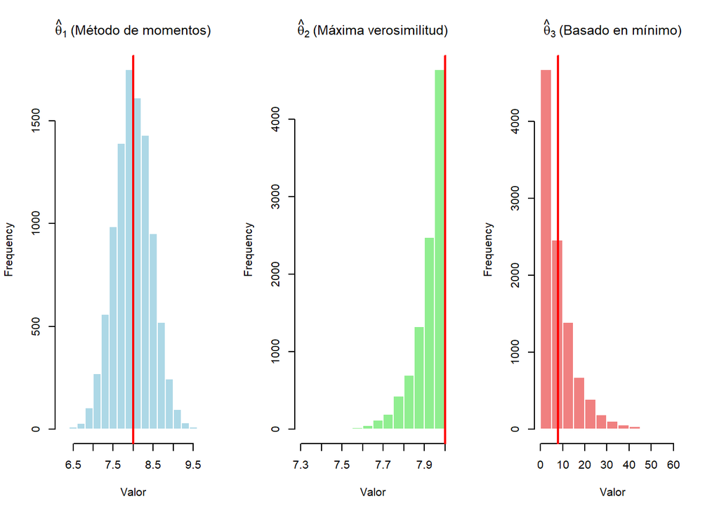

```r
par(mfrow = c(1, 3))
hist(theta1_vec, main = expression(hat(theta)[1]~"(Método de momentos)"),
     xlab = "Valor", col = "lightblue", border = "white")
abline(v = theta_real, col = "red", lwd = 2)
hist(theta2_vec, main = expression(hat(theta)[2]~"(Máxima verosimilitud)"),
     xlab = "Valor", col = "lightgreen", border = "white")
abline(v = theta_real, col = "red", lwd = 2)
hist(theta3_vec, main = expression(hat(theta)[3]~"(Basado en mínimo)"),
     xlab = "Valor", col = "lightcoral", border = "white")
abline(v = theta_real, col = "red", lwd = 2)
```

## Aquí unimos los 3 vectores con los estimadores en una matríz, estimamos el sesgo y las varianzas de los 3 estimadores y comparamos.

```r
par(mfrow = c(1, 1))
estimadores_df <- tibble(
  theta1 = theta1_vec,
  theta2 = theta2_vec,
  theta3 = theta3_vec
)
resultados_empiricos <- estimadores_df %>%
  summarise(

    sesgo_theta1 = mean(theta1) - theta_real,
    sesgo_theta2 = mean(theta2) - theta_real,
    sesgo_theta3 = mean(theta3) - theta_real,


    var_theta1 = var(theta1),
    var_theta2 = var(theta2),
    var_theta3 = var(theta3)
  )

resultados_teoricos <- tibble(
  sesgo_teorico_theta1 = 0,
  sesgo_teorico_theta2 = (n/(n+1))*theta_real - theta_real,
  sesgo_teorico_theta3 = 0,


  var_teorica_theta1 = theta_real^2 / (3*n),
  var_teorica_theta2 = (n*theta_real^2) / ((n+1)^2 * (n+2)),
  var_teorica_theta3 = (n*theta_real^2) / (n+2)
)

print(resultados_empiricos)
```

```
## # A tibble: 1 × 6
##   sesgo_theta1 sesgo_theta2 sesgo_theta3 var_theta1 var_theta2 var_theta3
##          <dbl>        <dbl>        <dbl>      <dbl>      <dbl>      <dbl>
## 1     -0.00754      -0.0800      -0.0524      0.210    0.00630       61.8
```

```r
print(resultados_teoricos)
```

```
## # A tibble: 1 × 6
##   sesgo_teorico_theta1 sesgo_teorico_theta2 sesgo_teorico_theta3
##                  <dbl>                <dbl>                <dbl>
## 1                    0              -0.0792                    0
## # ℹ 3 more variables: var_teorica_theta1 <dbl>, var_teorica_theta2 <dbl>,
## #   var_teorica_theta3 <dbl>
```

## Por último, hacemos la gráfica de cajas y bigotes de la matriz incluidos los 3 estimadores y demarcada con una línea horizontar mostramos el valor real del parámetro thetha.

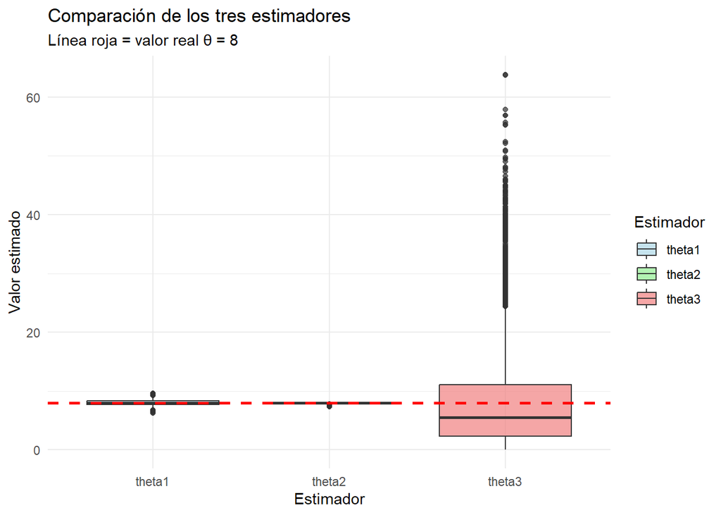

```r
estimadores_long <- estimadores_df %>%
  pivot_longer(cols = everything(), names_to = "Estimador", values_to = "Valor")

ggplot(estimadores_long, aes(x = Estimador, y = Valor, fill = Estimador)) +
  geom_boxplot(alpha = 0.7) +
  geom_hline(yintercept = theta_real, linetype = "dashed", color = "red", size = 1) +
  labs(title = "Comparación de los tres estimadores",
       subtitle = paste("Línea roja = valor real θ =", theta_real),
       y = "Valor estimado") +
  scale_fill_manual(values = c("lightblue", "lightgreen", "lightcoral")) +
  theme_minimal()
```

## 4. θ3 tiene la mayor varianza de los tres estimadores, seguido por θ1 y luego θ2, que es el más preciso pero sesgado.